# Automatic Feature Selection for High-Dimensional Climate Data in Hurricane Predictive Modeling

# 1 Data Explaination

- Sea Surface Temperature (SST)
- Pseudo-Wind Stress (PWS)
- Multivariate ENSO Index (MEI)
- Atlantic Multidecadal Oscillation (AMO)

Adding the required library and importing files

```r
library(httr)
library(XML)
library(RCurl)
library(curl)
library(ncdf4)
library(ncdf4.helpers)
library(glmnet)
library(glmnetUtils)
library(utils)
library(graphics)
```

## 1.1 Climate Time-Series Data

Downloading the required data

```r
#
# urlMEI <- "https://www.esrl.noaa.gov/psd/enso/mei/table.html"
# #htmlMEI <- getURL(urlMEI)
# htmlMEI <- readLines(curl(htmlMEI))
# htmlMEI=sub(pattern="(^<html>.*?YEAR)", replacement="YEAR", x=htmlMEI)
# htmlMEI=sub(pattern="\n\n\\(1\\).*\n", replacement="", x=htmlMEI)
# cat(htmlMEI, file="MEI.txt")
# DataMEI<-read.table("MEI.txt", header=TRUE, fill=TRUE)
#
#
# urlAMO <- "https://www.esrl.noaa.gov/psd/data/correlation/amon.us.data"
# #htmlAMO <- getURL(urlAMO)
# htmlAMO <- readLines(curl(urlAMO))
# htmlAMO <- sub(pattern="\n  -99.99\n  AMO.*\n$", replacement="", x=htmlAMO)
# htmlAMO <- sub(pattern="\n  AMO.*\n$", replacement="", x=htmlAMO)
# cat(htmlAMO, file="AMO.txt")
# DataAMO<-read.table("AMO.txt", skip=1, fill=TRUE, col.names = c("YEAR",month.abb))
```

## 1.2 Climate Field Data

### 1.2.1 Downloading and Reading in R

A plethora of field datasets are available through the **Earth System Research Lobaratory** and its **Physical Sciences Division**. Their webpage can be accessed from https://www.esrl.noaa.gov/psd/

The file format of these files are netCDF or `.nc`. A lightweight tool can open and visualize these files called `panoply`, which can be downloaded from https://www.giss.nasa.gov/tools/panoply/

Additionally, the library `ncdf4` in R allows loading and reading netCDF data. I followed the instruction [here](https://cran.r-project.org/web/packages/futureheatwaves/vignettes/starting_from_netcdf.html) for subsequent codings.

### 1.2.2 SST

We downloaded the ``Montly Mean'' dataset from https://www.esrl.noaa.gov/psd/data/gridded/data.noaa.ersst.html

Now, let us read the file and print its structure. First install `ncdf4`.

Then we use the `nc_open` to open a connection (**it will not read the file into memory**).

Printing the file will show a metadata about variables and other attributes.

```r
# download.file("ftp://ftp.cdc.noaa.gov/Datasets/noaa.ersst/sst.mnmean.v4.nc", destfile = "sst.mnmean.v4.nc",quiet=TRUE)
```

```r
ncSST <- nc_open("sst.mnmean.v4.nc")
#print(ncSST)
```

```r
# download.file("ftp://ftp.cdc.noaa.gov/Datasets/icoads/2degree/enh/upstr.mean.nc", destfile = "upstr.mean.nc", quite=TRUE)
```

```r
ncPWS <- nc_open("upstr.mean.nc")
#print(ncPWS)
```

```r
CONVERSION <- function(FieldData){
lon =ncvar_get(FieldData, varid="lon")
lon = ifelse(lon > 180, -(360 - lon), lon)  # So that close to Atlantic, lon is continuous
lat=ncvar_get(ncSST, varid="lat")
t=ncvar_get(ncSST, varid="time")
output <- list(lon=lon,lat=lat,t=t)
return(output)
}

RegionAveragedFieldData <- function(FieldData,Region,Date){
  #this function is calculating the average value of Field data in a region and time
  List <- CONVERSION(FieldData)
  lon <- List$lon
  lat <- List$lat
  t <- List$t

  t_index <- 12*(Date$year-1854)+Date$month
  lon_index <- which(lon>=Region$lon1 & lon<=Region$lon2)
  lat_index <- which(lat>=Region$lat1 & lat<=Region$lat2)
  DataMatrix <- nc.get.var.subset.by.axes(FieldData, names(FieldData$var)[2], axis.indices = list(X=lon_index, Y=lat_index, T=t_index))[,,1]
  ave <- sum(DataMatrix*(rep(1,length(lon_index))%*%t(cos(lat[lat_index]*pi/180))),   na.rm=TRUE)/sum(as.numeric(!is.na(DataMatrix))*(rep(1,length(lon_index))%*%t(cos(lat[lat_index]*pi/180))))
  return(ave)
}

MonthRegionAveragedFieldData <- function(FieldData,Region,Date){
  return(mean(sapply(Date$month, function(m){RegionAveragedFieldData(FieldData,Region,list(year=Date$year, month=m))})))
}
```

### 1.2.3 Utility Function

```r
years <- c(1950:2017)
mydata = read.csv("ZengModelData.csv")

ListSST <- CONVERSION(ncSST)
lon <- ListSST$lon
lat <- ListSST$lat
t <- ListSST$t

Region=list(lon1=-64, lon2=10, lat1=0, lat2=20)
RegionAveragedFieldData(ncSST,Region,Date=list(year=2017, month=3))
```

```
## [1] 26.40411
```

```r
MonthRegionAveragedFieldData(ncSST,Region,Date=list(year=2017, month=3:5))
```

```
## [1] 26.93983
```

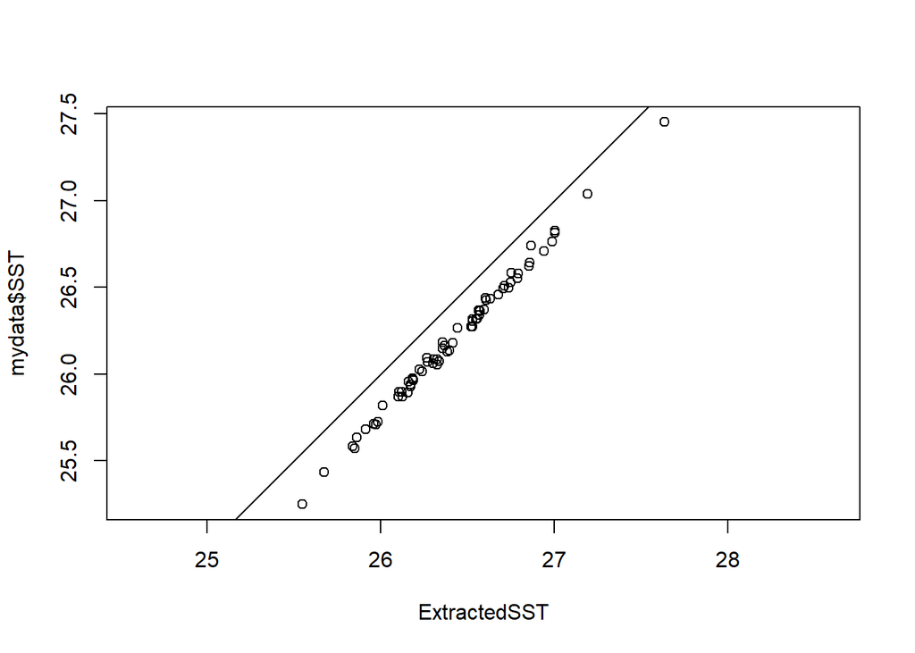

```r
ExtractedSST <- sapply(years,function(yr){MonthRegionAveragedFieldData(ncSST, Region, Date=list(year=yr, month=3:5))})
plot(ExtractedSST,mydata$SST,asp=1); abline(0,1)
```

```r
lonP <- seq(-100,20,by=10)
latP <- seq(-10,60, by=10)

SSTall <- matrix(0,length(years),(length(lonP)-1)*(length(latP)-1))
Regions <- data.frame(lon1=0, lon2=0, lat1=0, lat2=0)

for (i in 1:(length(lonP)-1)){
  for (j in 1:(length(latP)-1)){
    k=(i-1)*(length(latP)-1)+j
    #Region <- list(lon1=lonP[i],lon2=lonP[i+1],lat1=latP[j],lat2=latP[j+1])
    #Regions[k,] <- t(as.vector(Region))
    Regions[k,] <- c(lon1=lonP[i],lon2=lonP[i+1],lat1=latP[j],lat2=latP[j+1])
    SSTall[,k] <- sapply(years,function(yr){MonthRegionAveragedFieldData(ncSST, Region=as.list(Regions[k,]), Date=list(year=yr, month=3:5))})
  }
}

for (i in 1:(length(lonP)-1)){
  for (j in 1:(length(latP)-1)){
    k=(i-1)*(length(latP)-1)+j
    Regions[k,] <- c(lon1=lonP[i],lon2=lonP[i+1],lat1=latP[j],lat2=latP[j+1])
  }
}
```

```r
library(glmnet)
library(glmnetUtils)
library(utils)

ViableRegionIndex <- unique(which(!is.nan(SSTall), arr.ind=TRUE)[,2])
X=SSTall[,ViableRegionIndex]
X=cbind(X,mydata$PWS32)
X=cbind(X,mydata$MEI_AMO)
y=mydata$Hurricanes

cvfit <- cv.glmnet(X[1:67,],y[1:67],family="poisson", nfolds=5,type.measure="mae")

ChosenRegionIndex <- ViableRegionIndex[head(tail(which(abs(as.matrix(coef(cvfit,s=(cvfit$lambda.1se+cvfit$lambda.1se)/2)))>0.0001),-1)-1,-2)]
Regions[ChosenRegionIndex,]
```

```
##    lon1 lon2 lat1 lat2
## 30  -60  -50    0   10
## 44  -40  -30    0   10
## 51  -30  -20    0   10
## 56  -30  -20   50   60
## 58  -20  -10    0   10
```

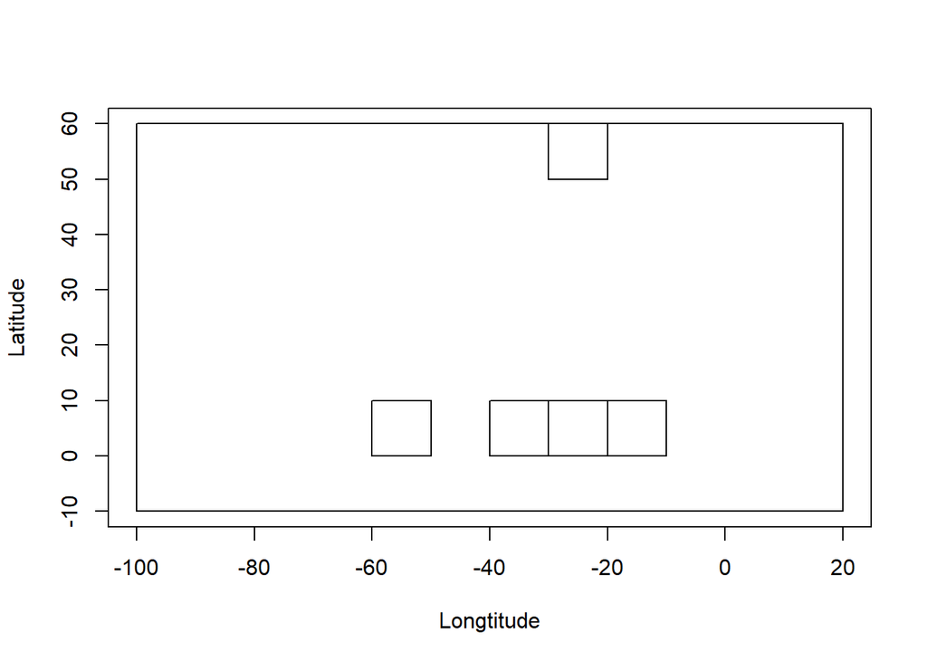

```r
library(graphics)

op <- par()
plot(0,0,xlim=c(lonP[1],tail(lonP,1)), ylim=c(latP[1],tail(latP,1)), type="n", xlab = "Longtitude", ylab = "Latitude")
rect(lonP[1],latP[1],tail(lonP,1),tail(latP,1))
for (k in 1:length(ChosenRegionIndex)){
    rect(xleft=Regions[ChosenRegionIndex[k],1], ybottom = Regions[ChosenRegionIndex[k],3], xright=Regions[ChosenRegionIndex[k],2], ytop = Regions[ChosenRegionIndex[k],4])
}
```

```r
mydata$SSTopt = sapply(years,function(yr){MonthRegionAveragedFieldData(ncSST, Region = list(lon1=-60, lon2=-20 , lat1= 0, lat2= 10), Date=list(year=yr, month=3:5))})
mydata$SSText = sapply(years,function(yr){MonthRegionAveragedFieldData(ncSST, Region = list(lon1=-60, lon2=10 , lat1= 0, lat2= 20), Date=list(year=yr, month=3:5))})
mydata$Hurricanes2 = mydata$Hurricanes-2
```

Davis, Kyle, Xubin Zeng, and Elizabeth A Ritchie. 2015. “A New Statistical Model for Predicting Seasonal North Atlantic Hurricane Activity.” *Weather and Forecasting* 30 (3): 730–41.